# Practical Machine Learning Course Project

Francesca Tantardini

27 gennaio 2017

The purpose of this project is to predict whether barbell lifts were performed correctly or incorrectly (in this case how incorrectly) on the base of the data from accelerometers on the belt, forearm, arm, and dumbell collected in http://groupware.les.inf.puc-rio.br/har#weight_lifting_exercises .

The training data set consists of 19622 observations of 160 variables. Between them are variables related to the participants and the time, which we do not consider in our analysis

```r
library(caret)
```

```r
training<-read.csv('pml-training.csv')
dim(training)
```

```
## [1] 19622   160
```

```r
indices<-match(c("X","user_name", "raw_timestamp_part_1", "raw_timestamp_part_2", "cvtd_timestamp", "new_window", "num_window"),  names(training))
training<-training[,-indices]
```

```r
head(training)
```

[output not shown]

[output cut: 258 more lines]

Moreover, it seems taht there are columns with a lot of NA values. We decide to exclude the variables which have more than 30% missing values, and we take only the rows without missing values.

```r
numOb<-dim(training)[1]
NAval<-colSums(is.na(training)) #number of missing values in every column
training<-training[,NAval<0.3*numOb]
training<-training[complete.cases(training),]
dim(training)
```

```
## [1] 19622    86
```

This is still a set with 86 variables. To further decrease this number, we remove the near zero variance predictors

```r
nsv<-nearZeroVar(training, saveMetrics=TRUE) #variables with near zero variance
training<-training[,!nsv$nzv]
dim(training)
```

```
## [1] 19622    53
```

We have now a training set with 53 variables. We build our predicting model with the help of the caret package. We use cross validation with K=10 through the option `trControl` of the function `train`. We first predict with trees using the method `rpart`

```r
set.seed(2104)
ctrl<-trainControl(method="cv", number=10) #to use cross validation
```

```r
modFit<-train(classe ~., method="rpart", data=training, trControl=ctrl)
```

We predict the factor variable `classe`, which contains five levels: A (exercise correct) and B, C, D, E (incorrect in four different ways) with all other variables in the training data set. The accuracy on the training set is though quite low, as we can see with the help of the `confusionMatrix` function:

```r
confusionMatrix(predict(modFit, training), training$classe)
```

```
## Confusion Matrix and Statistics
##
##           Reference
## Prediction    A    B    C    D    E
##          A 5080 1581 1587 1449  524
##          B   81 1286  108  568  486
##          C  405  930 1727 1199  966
##          D    0    0    0    0    0
##          E   14    0    0    0 1631
##
## Overall Statistics
##
##                Accuracy : 0.4956
##                  95% CI : (0.4885, 0.5026)
##     No Information Rate : 0.2844
##     P-Value [Acc > NIR] : < 2.2e-16
##
##                   Kappa : 0.3407
##  Mcnemar's Test P-Value : NA
##
## Statistics by Class:
##
##                      Class: A Class: B Class: C Class: D Class: E
## Sensitivity            0.9104  0.33869  0.50468   0.0000  0.45218
## Specificity            0.6339  0.92145  0.78395   1.0000  0.99913
## Pos Pred Value         0.4970  0.50850  0.33040      NaN  0.99149
## Neg Pred Value         0.9468  0.85310  0.88225   0.8361  0.89008
## Prevalence             0.2844  0.19351  0.17440   0.1639  0.18382
## Detection Rate         0.2589  0.06554  0.08801   0.0000  0.08312
## Detection Prevalence   0.5209  0.12889  0.26638   0.0000  0.08383
## Balanced Accuracy      0.7721  0.63007  0.64431   0.5000  0.72565
```

We see that too many observations are classified as correct (A) although they are not.

Looking at the `modFit$finalModel`, we can see how the decisions are made to classify the observations.

```r
modFit$finalModel
```

```
## n= 19622
##
## node), split, n, loss, yval, (yprob)
##       * denotes terminal node
##
##  1) root 19622 14042 A (0.28 0.19 0.17 0.16 0.18)
##    2) roll_belt< 130.5 17977 12411 A (0.31 0.21 0.19 0.18 0.11)
##      4) pitch_forearm< -33.95 1578    10 A (0.99 0.0063 0 0 0) *
##      5) pitch_forearm>=-33.95 16399 12401 A (0.24 0.23 0.21 0.2 0.12)
##       10) magnet_dumbbell_y< 439.5 13870  9953 A (0.28 0.18 0.24 0.19 0.11)
##         20) roll_forearm< 123.5 8643  5131 A (0.41 0.18 0.18 0.17 0.061) *
##         21) roll_forearm>=123.5 5227  3500 C (0.077 0.18 0.33 0.23 0.18) *
##       11) magnet_dumbbell_y>=439.5 2529  1243 B (0.032 0.51 0.043 0.22 0.19) *
##    3) roll_belt>=130.5 1645    14 E (0.0085 0 0 0 0.99) *
```

We make some plots of the variables used in the tree and we colour by the class. It seems that the predictor are quite weak.

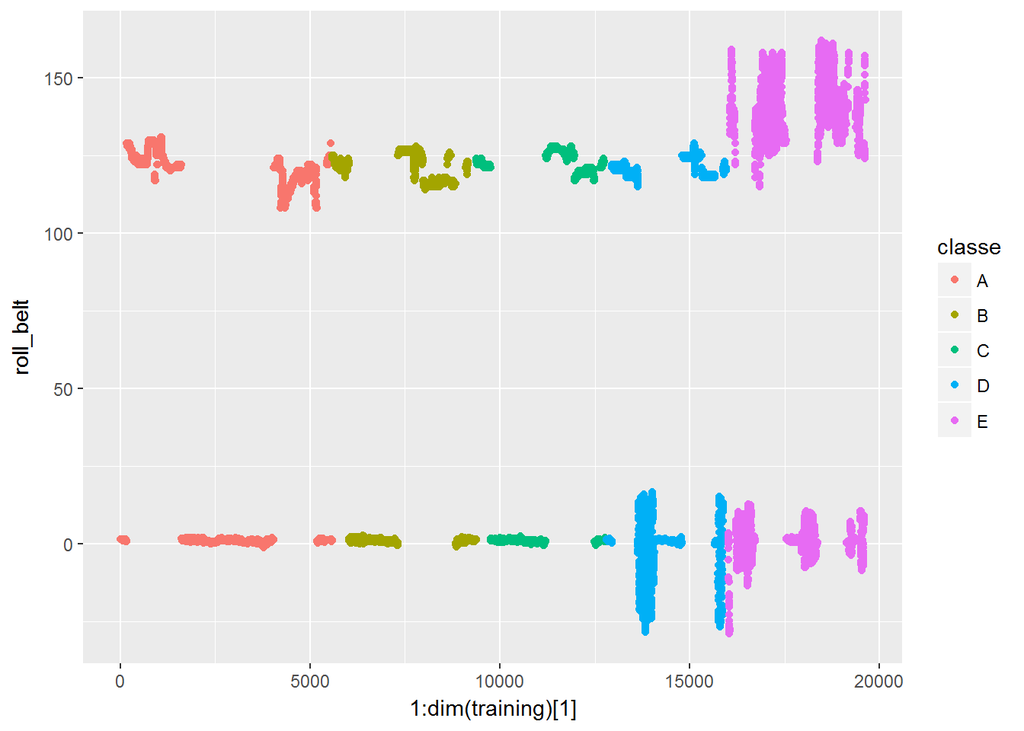

```r
qplot(1:dim(training)[1], roll_belt, data=training, colour=classe)
```

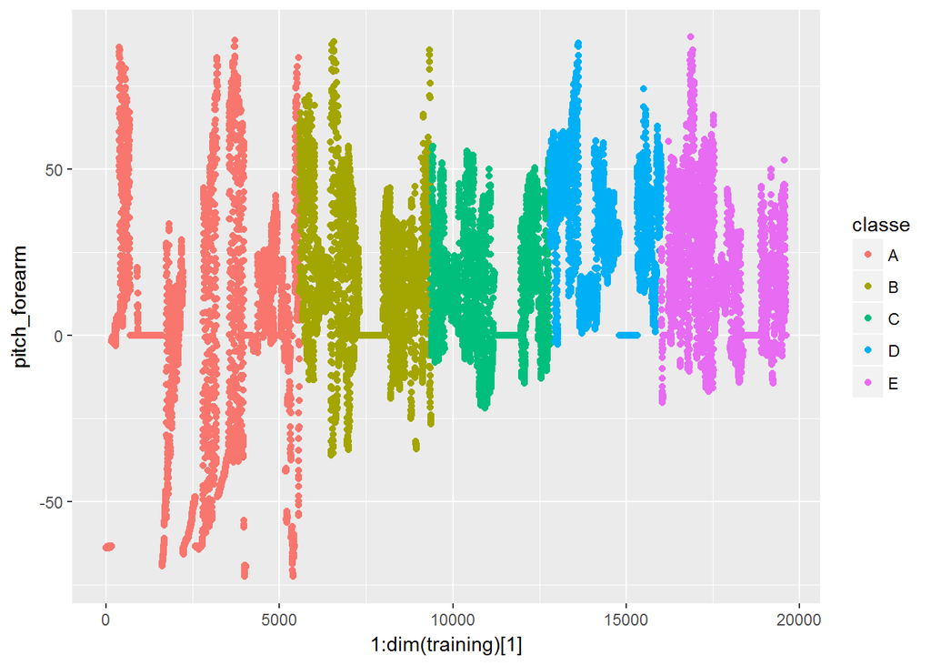

```r
qplot(1:dim(training)[1], pitch_forearm, data=training, colour=classe)
```

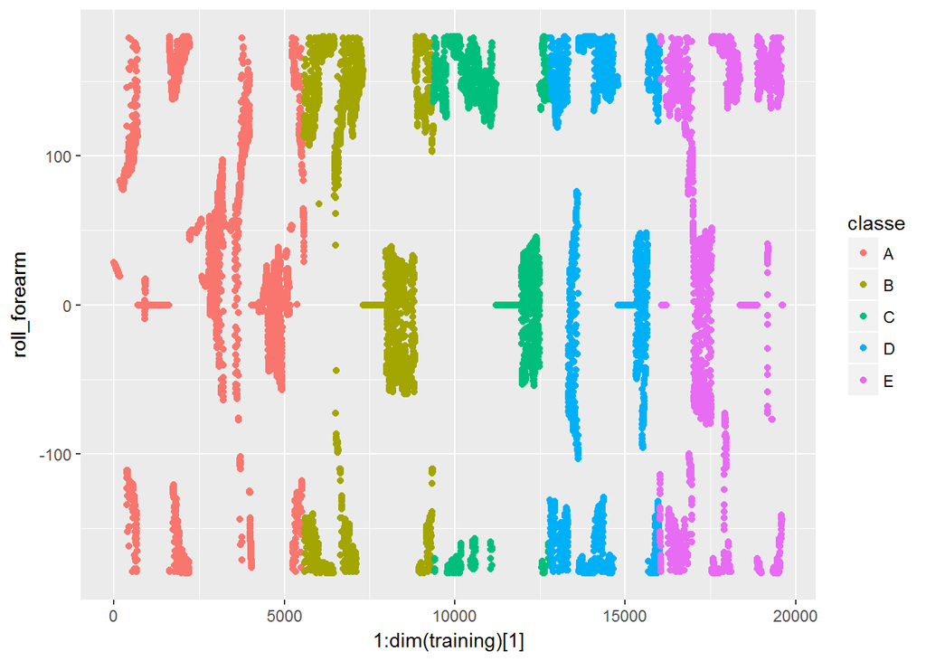

```r
qplot(1:dim(training)[1], roll_forearm, data=training, colour=classe)
```

We therefore use boosting ( method `gbm`), again with cross validation, in order to increase the accuracy.

```r
modFitB<-train(classe~., method="gbm", data=training, trControl=ctrl, verbose=FALSE)
```

Using the `confusionMatrix` function

```r
confusionMatrix(predict(modFitB, training), training$classe)
```

```
## Confusion Matrix and Statistics
##
##           Reference
## Prediction    A    B    C    D    E
##          A 5520   89    0    2    5
##          B   42 3630   70   12   26
##          C   11   74 3311   86   24
##          D    4    2   35 3100   39
##          E    3    2    6   16 3513
##
## Overall Statistics
##
##                Accuracy : 0.9721
##                  95% CI : (0.9697, 0.9743)
##     No Information Rate : 0.2844
##     P-Value [Acc > NIR] : < 2.2e-16
##
##                   Kappa : 0.9647
##  Mcnemar's Test P-Value : < 2.2e-16
##
## Statistics by Class:
##
##                      Class: A Class: B Class: C Class: D Class: E
## Sensitivity            0.9892   0.9560   0.9676   0.9639   0.9739
## Specificity            0.9932   0.9905   0.9880   0.9951   0.9983
## Pos Pred Value         0.9829   0.9603   0.9444   0.9748   0.9924
## Neg Pred Value         0.9957   0.9895   0.9931   0.9929   0.9942
## Prevalence             0.2844   0.1935   0.1744   0.1639   0.1838
## Detection Rate         0.2813   0.1850   0.1687   0.1580   0.1790
## Detection Prevalence   0.2862   0.1926   0.1787   0.1621   0.1804
## Balanced Accuracy      0.9912   0.9733   0.9778   0.9795   0.9861
```

We can see that now the accuracy on the training set is 0.97

We expect that the out of sample error greater is than the error on the training set that we use to build our model.

We use our predictor to predict the class of 20 observations in the test set:

```r
testing<-read.csv('pml-testing.csv')
predict(modFitB, testing)
```

```
##  [1] B A B A A E D B A A B C B A E E A B B B
## Levels: A B C D E
```